# Figures 2A and S4A

Paired Random Forest for biomarker identification (Figure S4A); ROC curves with 95% CI (Figure 2A)

# 1 Introduction

Figure S4A: paired bagging Random Forest to identify cytokines that distinguish pre-treatment (W0) from post-treatment visits (16, 24, and 72 weeks) in patients with successful treatment outcome (n = 33). For each bootstrap iteration, patients are sampled with replacement and both their visits are included, preserving the paired structure. Importance scores are averaged across all valid iterations.

Figure 2A: ROC curves with 95% bootstrap confidence intervals for the top cytokines from each RF comparison.

# 2 Load packages

```r
library(readxl)
library(DataExplorer)
library(dplyr)
library(tidyr)
library(ggplot2)
library(randomForest)
library(caret)
library(pROC)
library(writexl)
```

# 3 Define file paths

```r
input_file       <- "Input/Cytokines_cleaned_log10_Predict-TB.xlsx"
output_fig2a_s4a <- "Output/02. Figure_2A_S4A"

dir.create(output_fig2a_s4a, recursive = TRUE, showWarnings = FALSE)
```

# 4 Load data

```r
all_data <- read_excel(input_file, sheet = 1)

head(all_data)
```

```
# A tibble: 6 × 43
  barcode    ID1      Visit `Visit Unit` Condition  BDNF CCL11 Factor_VII ICAM_1
  <chr>      <chr>    <chr> <chr>        <chr>     <dbl> <dbl>      <dbl>  <dbl>
1 0408237248 PD-1-2-… 0     Day          IL1B       4.15  2.79       5.18   3
2 0408237256 PD-1-2-… 24    Wk           LPS        4.18  2.73       5.36   4.52
3 0408237264 PD-1-2-… 72    Wk           Null       4.49  2.48       5.13   4.79
4 0408237272 PD-1-2-… 0     Day          LPS        4.11  2.68       5.35   5.11
5 0408237280 PD-1-2-… 24    Wk           Null       4.26  2.12       5.46   4.49
6 0408237288 PD-1-2-… 24    Wk           Null       4.34  2.85       5.39   4.53
# ℹ 34 more variables: IL_1_alpha <dbl>, IL_1_beta <dbl>, IL_10 <dbl>,
#   IL_12p40 <dbl>, IL_12p70 <dbl>, IL_18 <dbl>, IL_1RA <dbl>, IL_3 <dbl>,
#   IL_4 <dbl>, IL_6 <dbl>, IL_7 <dbl>, IL_8 <dbl>, CCL2 <dbl>, CCL3 <dbl>,
#   MMP_3 <dbl>, TNF <dbl>, VEGF <dbl>, IFNG <dbl>, IL_2 <dbl>, pan_IFNA <dbl>,
#   IFNB <dbl>, BMI <chr>, MGIT <chr>, XPERT_cycle_0 <chr>, Smear <chr>,
#   Comments <chr>, Arm <chr>, Age <chr>, Sex <chr>, Fever_0 <chr>,
#   Temp_0 <chr>, Previous_TB <chr>, Smoking <chr>, Smoking_years <chr>
```

```r
dim(all_data)
```

```
[1] 588  43
```

# 5 Define cytokine columns

```r
cytokine_cols <- c(
  "BDNF", "CCL11", "Factor_VII", "ICAM_1",
  "IL_1_alpha", "IL_1_beta", "IL_10", "IL_12p40",
  "IL_12p70", "IL_18", "IL_1RA", "IL_3", "IL_4",
  "IL_6", "IL_7", "IL_8", "CCL2", "CCL3",
  "MMP_3", "TNF", "VEGF", "IFNG", "IL_2",
  "pan_IFNA", "IFNB"
)
```

# 6 Filter to successful treatment outcome

```r
protein_data <- all_data %>%
  filter(Comments == "success") %>%
  select(ID1, Visit, Condition, all_of(cytokine_cols))
```

# 7 Reshape to wide format

```r
protein_log_wide <- protein_data %>%
  pivot_longer(
    cols      = all_of(cytokine_cols),
    names_to  = "Cytokine",
    values_to = "Value"
  ) %>%
  mutate(combined_name = paste(Condition, Cytokine, sep = "_")) %>%
  select(-Condition, -Cytokine) %>%
  pivot_wider(
    names_from  = combined_name,
    values_from = Value
  )
```

# 8 Hyperparameter configuration

Each comparison has its own configuration and can be tuned independently to achieve the lowest error rate.

```r
rf_config <- list(

  W0_W16 = list(
    visits             = c("0", "16"),
    variance_threshold = 0.01,
    n_random           = 10,
    n_bags             = 100,
    ntree              = 600,
    k_folds            = 5,
    mtry_range         = NULL,
    n_bootstrap_roc    = 2000,
    top_n_cytokines    = 4
  ),

  W0_W24 = list(
    visits             = c("0", "24"),
    variance_threshold = 0.01,
    n_random           = 10,
    n_bags             = 100,
    ntree              = 600,
    k_folds            = 5,
    mtry_range         = NULL,
    n_bootstrap_roc    = 2000,
    top_n_cytokines    = 4
  ),

  W0_W72 = list(
    visits             = c("0", "72"),
    variance_threshold = 0.01,
    n_random           = 10,
    n_bags             = 100,
    ntree              = 600,
    k_folds            = 5,
    mtry_range         = NULL,
    n_bootstrap_roc    = 2000,
    top_n_cytokines    = 4
  )
)
```

# 9 Helper functions

`prepare_rf_data`: filters to the visit pair, sets Visit as an ordered factor, removes low-variance features, and adds random reference features drawn from the same distribution as the cytokine values.

```r
prepare_rf_data <- function(wide_data, config) {
  visits             <- config$visits
  variance_threshold <- config$variance_threshold
  n_random           <- config$n_random

  data_filt <- wide_data %>%
    filter(Visit %in% visits) %>%
    mutate(Visit = factor(Visit, levels = visits))

    # Rename factor levels to valid R variable names for caret compatibility
  levels(data_filt$Visit) <- paste0("W", levels(data_filt$Visit))

  feature_cols <- setdiff(names(data_filt), c("ID1", "Visit"))
  variances    <- sapply(data_filt[, feature_cols], var, na.rm = TRUE)
  retained     <- names(variances[variances > variance_threshold])
  data_filt    <- data_filt[, c("ID1", "Visit", retained)]

  cyt_vals  <- unlist(data_filt[, retained], use.names = FALSE)
  rand_mean <- mean(cyt_vals, na.rm = TRUE)
  rand_sd   <- sd(cyt_vals,   na.rm = TRUE)

  set.seed(123)
  random_cols <- paste0("Random_", seq_len(n_random))
  for (col in random_cols) {
    data_filt[[col]] <- rnorm(nrow(data_filt), mean = rand_mean, sd = rand_sd)
  }

  cat(sprintf(
    "Visits: %s | Rows: %d | Features retained: %d | Random added: %d\n",
    paste(visits, collapse = " vs "), nrow(data_filt),
    length(retained), n_random
  ))

  list(data = data_filt, retained = retained, random_cols = random_cols)
}
```

`tune_rf`: tunes `mtry` using patient-level grouped k-fold CV. All patients are in the CV pool since there is no held-out test set.

```r
tune_rf <- function(prep, config) {
  data       <- prep$data
  k_folds    <- config$k_folds
  ntree      <- config$ntree
  mtry_range <- config$mtry_range

  patient_ids <- data$ID1
  data_train  <- data[, !names(data) %in% "ID1"]
  n_pred      <- ncol(data_train) - 1

  if (is.null(mtry_range)) {
    mtry_range <- seq(2, floor(sqrt(n_pred)), by = 1)
  }

  set.seed(123)
  group_folds <- groupKFold(patient_ids, k = k_folds)

  train_f1 <- unique(patient_ids[group_folds[[1]]])
  test_f1  <- unique(patient_ids)[!unique(patient_ids) %in% train_f1]
  cat(sprintf(
    "Fold 1 leakage check - Train: %d | Test: %d | Overlap: %d\n",
    length(train_f1), length(test_f1),
    length(intersect(train_f1, test_f1))
  ))

  ctrl <- trainControl(
    method          = "cv",
    index           = group_folds,
    classProbs      = TRUE,
    savePredictions = "final",
    summaryFunction = twoClassSummary,
    verboseIter     = FALSE
  )

  set.seed(123)
  tuned <- tryCatch(
    train(
      Visit ~ .,
      data       = data_train,
      method     = "rf",
      trControl  = ctrl,
      tuneGrid   = expand.grid(mtry = mtry_range),
      ntree      = ntree,
      metric     = "ROC",
      importance = TRUE
    ),
    error = function(e) { message("Tuning failed: ", e$message); NULL }
  )

  if (is.null(tuned)) stop("RF tuning failed.")

  best_mtry <- tuned$bestTune$mtry
  cat(sprintf("Best mtry: %d\n", best_mtry))
  print(tuned)

  best_mtry
}
```

`bag_rf`: paired patient-level bootstrap RF. For each iteration, patients are sampled with replacement and both visits for each sampled patient are included. Importance scores are averaged and SD computed across all valid iterations.

```r
bag_rf <- function(prep, best_mtry, config) {
  data   <- prep$data
  n_bags <- config$n_bags
  ntree  <- config$ntree

  patient_ids <- unique(data$ID1)
  n_patients  <- length(patient_ids)
  imp_list    <- vector("list", n_bags)

  set.seed(123)
  for (b in seq_len(n_bags)) {
    sampled <- sample(patient_ids, n_patients, replace = TRUE)

    boot_data <- do.call(rbind, lapply(sampled, function(p) {
      data[data$ID1 == p, ]
    }))

    train_data       <- boot_data[, !names(boot_data) %in% "ID1"]
    train_data$Visit <- droplevels(train_data$Visit)

    rf <- tryCatch(
      randomForest(
        Visit ~ .,
        data       = train_data,
        ntree      = ntree,
        mtry       = best_mtry,
        importance = TRUE
      ),
      error = function(e) NULL
    )

    if (!is.null(rf)) {
      imp_list[[b]] <- importance(rf, type = 1, scale = TRUE)[, "MeanDecreaseAccuracy"]
    }
  }

  imp_list <- Filter(Negate(is.null), imp_list)
  n_valid  <- length(imp_list)
  imp_mat  <- do.call(cbind, imp_list)

  cat(sprintf("Valid bags: %d / %d\n", n_valid, n_bags))

  list(
    avg_importance = rowMeans(imp_mat),
    sd_importance  = apply(imp_mat, 1, sd),
    n_valid_bags   = n_valid
  )
}
```

`plot_importance_fig`: dot plot of the top features ranked by average MDA. Features above the random threshold are shown in dark red. Rendered inline and saved to file.

```r
plot_importance_fig <- function(importance_vals,
                                rand_threshold,
                                title     = "Variable importance",
                                save_path = NULL,
                                filename  = "importance.png",
                                top_n     = 75) {

  sorted_vals <- sort(importance_vals, decreasing = TRUE)
  n_show      <- min(top_n, length(sorted_vals))
  top_vals    <- sorted_vals[seq_len(n_show)]
  y_pos       <- n_show:1
  dot_colors  <- ifelse(top_vals > rand_threshold, "darkred", "gray60")
  n_sig       <- sum(
    importance_vals[!grepl("^Random_", names(importance_vals))] > rand_threshold
  )

  draw_plot <- function() {
    par(mar = c(5, 12, 4, 2))

    x_min <- min(top_vals) * ifelse(min(top_vals) < 0, 1.1, 0.9)
    x_max <- max(top_vals) * 1.2

    plot(top_vals, y_pos,
         type = "n", xlim = c(x_min, x_max),
         yaxt = "n", xaxt = "n",
         xlab = "Mean Decrease in Accuracy", ylab = "", main = title)

    axis(1, at = seq(floor(min(top_vals)), ceiling(max(top_vals)),
                     by = max(0.5, round(ceiling(max(top_vals)) / 5, 1))))
    abline(h = y_pos, lty = "dotted", col = "gray80")
    points(top_vals, y_pos, pch = 16, cex = 1.2, col = dot_colors)
    text(par("usr")[1], y_pos, labels = names(top_vals),
         pos = 2, xpd = TRUE, col = "black", cex = 0.9)
    abline(v = rand_threshold, col = "gray40", lty = 2, lwd = 2)

    usr <- par("usr")
    text(usr[2] - (usr[2] - usr[1]) * 0.02,
         usr[3] + (usr[4] - usr[3]) * 0.05,
         labels = paste("Random threshold:", round(rand_threshold, 3)),
         adj = c(1, 0), cex = 1, col = "gray40")
    mtext(paste(n_sig, "cytokines above random threshold"),
          side = 3, line = 0.5, cex = 0.8)
  }

  draw_plot()

  if (!is.null(save_path)) {
    png(file.path(save_path, filename), width = 2600, height = 4500, res = 300)
    draw_plot()
    dev.off()
    cat(sprintf("Saved: %s\n", filename))
  }

  invisible(NULL)
}
```

`run_roc`: paired patient-level bootstrap ROC. week 0 is always the reference class (first level of the Visit factor).

```r
run_roc <- function(data, cytokine, n_bootstrap = 2000) {
  tryCatch({
    roc_obj <- roc(
      response  = data$Visit == levels(data$Visit)[1],
      predictor = data[[cytokine]],
      direction = "<",
      quiet     = TRUE
    )

    patient_ids <- unique(data$ID1)
    n_patients  <- length(patient_ids)
    boot_aucs   <- numeric(n_bootstrap)

    for (b in seq_len(n_bootstrap)) {
      sampled   <- sample(patient_ids, n_patients, replace = TRUE)
      boot_data <- do.call(rbind, lapply(sampled, function(p) data[data$ID1 == p, ]))

      boot_roc <- tryCatch(
        roc(boot_data$Visit == levels(data$Visit)[1], boot_data[[cytokine]],
            quiet = TRUE, direction = "<"),
        error = function(e) NULL
      )
      boot_aucs[b] <- if (!is.null(boot_roc)) as.numeric(auc(boot_roc)) else NA
    }

    boot_aucs <- boot_aucs[!is.na(boot_aucs)]

    list(
      roc          = roc_obj,
      auc          = auc(roc_obj),
      ci_lower     = quantile(boot_aucs, 0.025),
      ci_upper     = quantile(boot_aucs, 0.975),
      n_valid_boot = length(boot_aucs)
    )
  }, error = function(e) {
    message("ROC failed for ", cytokine, ": ", e$message)
    NULL
  })
}
```

`plot_roc_curves`: ROC curves for a named list of cytokines with AUC and CI in the legend. Rendered inline and saved to file.

```r
plot_roc_curves <- function(roc_results,
                             title     = "ROC curves",
                             save_path = NULL,
                             filename  = "roc.png") {

  colors <- c("#000000", "#377EB8", "#4DAF4A", "#984EA3")

  draw_plot <- function() {
    par(mar = c(5, 5, 4, 2))
    plot(roc_results[[1]]$roc,
         col = colors[1], main = title,
         xlab = "1 - Specificity", ylab = "Sensitivity",
         lwd = 2, cex.main = 1.2, cex.lab = 1.1, cex.axis = 1.0,
         legacy.axes = TRUE)

    if (length(roc_results) > 1) {
      for (i in seq(2, length(roc_results))) {
        plot(roc_results[[i]]$roc, col = colors[i], add = TRUE, lwd = 2)
      }
    }

    grid()

    legend("bottomright",
           legend = sapply(names(roc_results), function(cyt) {
             r <- roc_results[[cyt]]
             sprintf("%s  AUC = %.2f (95%% CI: %.2f - %.2f)",
                     cyt, as.numeric(r$auc), r$ci_lower, r$ci_upper)
           }),
           col = colors[seq_along(roc_results)],
           lty = 1, lwd = 2, cex = 0.9, bg = "white", box.lwd = 1)
  }

  draw_plot()

  if (!is.null(save_path)) {
    png(file.path(save_path, filename), width = 1800, height = 2000,
        res = 300, bg = "white")
    draw_plot()
    dev.off()
    cat(sprintf("Saved: %s\n", filename))
  }

  invisible(NULL)
}
```

`build_summary`: summary table with AUC, bootstrap CI, and optimal threshold metrics (Youden index).

```r
build_summary <- function(roc_results) {
  get_coords <- function(roc_obj) {
    opt <- coords(roc_obj, x = "best", best.method = "youden",
                  ret = c("threshold", "sensitivity", "specificity", "ppv", "npv"),
                  transpose = FALSE)
    if (nrow(opt) > 1) opt <- opt[which.max(opt$sensitivity), ]
    opt
  }

  do.call(rbind, lapply(names(roc_results), function(cyt) {
    r   <- roc_results[[cyt]]
    opt <- tryCatch(get_coords(r$roc), error = function(e) NULL)
    if (is.null(opt)) return(NULL)

    data.frame(
      Biomarker         = cyt,
      AUC               = round(as.numeric(r$auc), 3),
      CI_Lower          = round(r$ci_lower, 3),
      CI_Upper          = round(r$ci_upper, 3),
      Optimal_Threshold = round(opt$threshold, 4),
      Sensitivity_pct   = round(opt$sensitivity * 100, 1),
      Specificity_pct   = round(opt$specificity * 100, 1),
      PPV_pct           = round(opt$ppv * 100, 1),
      NPV_pct           = round(opt$npv * 100, 1),
      Youden_J          = round(opt$sensitivity + opt$specificity - 1, 3),
      N_Bootstrap       = r$n_valid_boot,
      stringsAsFactors  = FALSE
    )
  }))
}
```

# 10 week 0 vs week 16

```r
prep_16 <- prepare_rf_data(protein_log_wide, rf_config$W0_W16)
```

```
Visits: 0 vs 16 | Rows: 62 | Features retained: 87 | Random added: 10
```

```r
mtry_16 <- tune_rf(prep_16, rf_config$W0_W16)
```

```
Fold 1 leakage check - Train: 25 | Test: 8 | Overlap: 0
Best mtry: 2
Random Forest

62 samples
97 predictors
 2 classes: 'W0', 'W16'

No pre-processing
Resampling: Cross-Validated (10 fold)
Summary of sample sizes: 48, 49, 44, 54, 53
Resampling results across tuning parameters:

  mtry  ROC        Sens       Spec
  2     0.9523810  0.8928571  0.8222222
  3     0.9465476  0.8642857  0.7822222
  4     0.9465476  0.8428571  0.7822222
  5     0.9511905  0.8642857  0.8100000
  6     0.9417857  0.8142857  0.8322222
  7     0.9411905  0.8142857  0.8722222
  8     0.9459524  0.8142857  0.8722222
  9     0.9421737  0.8642857  0.8500000

ROC was used to select the optimal model using the largest value.
The final value used for the model was mtry = 2.
```

```r
bag_16  <- bag_rf(prep_16, mtry_16, rf_config$W0_W16)
```

```
Valid bags: 100 / 100
```

```r
avg_imp_16   <- bag_16$avg_importance
is_rand_16   <- grepl("^Random_", names(avg_imp_16))
threshold_16 <- mean(avg_imp_16[is_rand_16])
cyt_mda_16   <- avg_imp_16[!is_rand_16]
sig_16       <- sort(cyt_mda_16[cyt_mda_16 > threshold_16], decreasing = TRUE)
top_cyts_16  <- names(head(sig_16, rf_config$W0_W16$top_n_cytokines))

cat(sprintf(
  "Threshold: %.3f | Cytokines above threshold: %d | Top %d: %s\n",
  threshold_16, length(sig_16), length(top_cyts_16),
  paste(top_cyts_16, collapse = ", ")
))
```

```
Threshold: 3.409 | Cytokines above threshold: 58 | Top 4: Mtb_Ag_IL_1RA, LPS_IL_1RA, Null_IL_8, Null_IL_1RA
```

```r
print(sig_16)
```

```
    Mtb_Ag_IL_1RA        LPS_IL_1RA         Null_IL_8       Null_IL_1RA
         6.357136          6.021985          5.879489          5.789818
        IL1B_IL_8       IL1B_IL_1RA         Null_IL_6 Mtb_Ag_Factor_VII
         5.652126          5.588493          5.350143          5.239309
        IL1B_IL_6   Null_Factor_VII       Mtb_Ag_IL_6          IL1B_TNF
         5.185812          5.158597          5.105757          5.082264
  IL1B_Factor_VII       Mtb_Ag_IL_8         Null_IFNG       Mtb_Ag_IFNG
         5.022393          5.012021          4.961507          4.953868
    IL1B_IL_12p40        Mtb_Ag_TNF    LPS_Factor_VII       Mtb_Ag_BDNF
         4.917917          4.898698          4.827054          4.797924
        IL1B_BDNF         IL1B_CCL3     Null_IL_12p40          LPS_BDNF
         4.757544          4.754662          4.639996          4.588108
       Null_IL_18        IL1B_IL_18         IL1B_IFNG         Null_BDNF
         4.563352          4.551255          4.546155          4.446137
       IL1B_IL_10       Mtb_Ag_IL_2        Null_CCL11      Mtb_Ag_CCL11
         4.416748          4.411028          4.400001          4.302921
     Mtb_Ag_IL_18         LPS_CCL11         Null_VEGF   Mtb_Ag_IL_12p40
         4.271201          4.258882          4.225226          4.201280
         LPS_IL_8        IL1B_MMP_3          LPS_IFNG       Mtb_Ag_CCL3
         4.174878          4.161396          4.149370          4.122706
       IL1B_CCL11         LPS_IL_18           LPS_TNF         LPS_MMP_3
         4.116415          4.105655          4.031198          4.009557
   LPS_IL_1_alpha      Mtb_Ag_MMP_3        Null_MMP_3      LPS_IL_12p40
         3.961573          3.951560          3.867593          3.852714
         LPS_VEGF     Mtb_Ag_ICAM_1         Null_CCL2  Mtb_Ag_IL_1_beta
         3.807500          3.800201          3.740951          3.718175
         LPS_CCL2          LPS_IL_6       IL1B_ICAM_1     LPS_IL_1_beta
         3.708180          3.685780          3.648709          3.565936
     LPS_pan_IFNA         IL1B_CCL2
         3.476696          3.426472
```

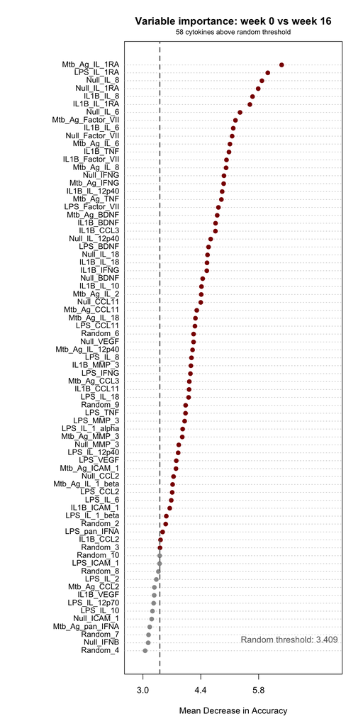

```
Saved: S4A_importance_W0_W16.png
```

```r
plot_importance_fig(
  importance_vals = avg_imp_16,
  rand_threshold  = threshold_16,
  title           = "Variable importance: week 0 vs week 16",
  save_path       = output_fig2a_s4a,
  filename        = "S4A_importance_W0_W16.png"
)
```

```r
set.seed(123)
roc_16 <- list()
for (cyt in top_cyts_16) {
  cat(sprintf("ROC: %s\n", cyt))
  roc_16[[cyt]] <- run_roc(
    data        = prep_16$data,
    cytokine    = cyt,
    n_bootstrap = rf_config$W0_W16$n_bootstrap_roc
  )
}
```

```
ROC: Mtb_Ag_IL_1RA
ROC: LPS_IL_1RA
ROC: Null_IL_8
ROC: Null_IL_1RA
```

```r
roc_16 <- Filter(Negate(is.null), roc_16)

for (cyt in names(roc_16)) {
  r <- roc_16[[cyt]]
  cat(sprintf("  %-20s AUC: %.3f (95%% CI: %.3f - %.3f) | Bootstrap n: %d\n",
              cyt, as.numeric(r$auc), r$ci_lower, r$ci_upper, r$n_valid_boot))
}
```

```
  Mtb_Ag_IL_1RA        AUC: 0.897 (95% CI: 0.828 - 0.958) | Bootstrap n: 2000
  LPS_IL_1RA           AUC: 0.878 (95% CI: 0.801 - 0.946) | Bootstrap n: 2000
  Null_IL_8            AUC: 0.843 (95% CI: 0.760 - 0.927) | Bootstrap n: 2000
  Null_IL_1RA          AUC: 0.845 (95% CI: 0.765 - 0.928) | Bootstrap n: 2000
```

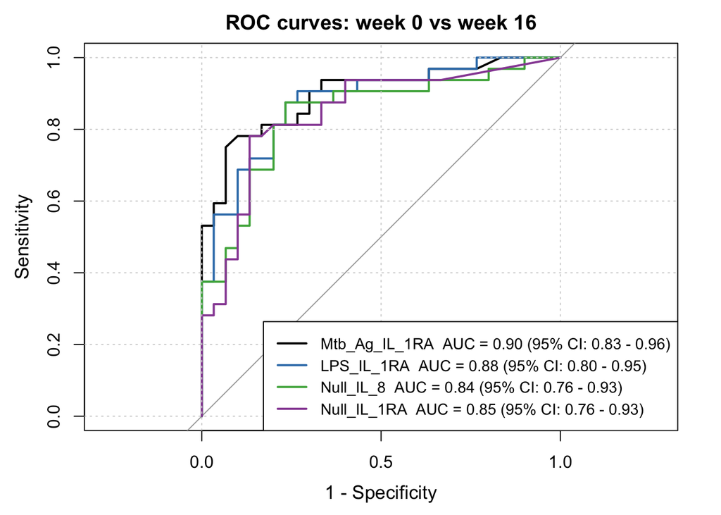

```
Saved: 2A_ROC_W0_W16.png
```

```r
plot_roc_curves(
  roc_results = roc_16,
  title       = "ROC curves: week 0 vs week 16",
  save_path   = output_fig2a_s4a,
  filename    = "2A_ROC_W0_W16.png"
)
```

```r
summary_16 <- build_summary(roc_16)
print(summary_16)
```

```
          Biomarker   AUC CI_Lower CI_Upper Optimal_Threshold Sensitivity_pct
2.5%  Mtb_Ag_IL_1RA 0.897    0.828    0.958            3.1860            75.0
2.5%1    LPS_IL_1RA 0.878    0.801    0.946            3.6821            87.5
2.5%2     Null_IL_8 0.843    0.760    0.927            2.2844            87.5
2.5%3   Null_IL_1RA 0.845    0.765    0.928            2.2871            78.1
      Specificity_pct PPV_pct NPV_pct Youden_J N_Bootstrap
2.5%             93.3    92.3    77.8    0.683        2000
2.5%1            76.7    80.0    85.2    0.642        2000
2.5%2            76.7    80.0    85.2    0.642        2000
2.5%3            86.7    86.2    78.8    0.648        2000
```

```r
write_xlsx(summary_16, file.path(output_fig2a_s4a, "ROC_summary_W0_W16.xlsx"))
```

# 11 week 0 vs week 24

```r
prep_24 <- prepare_rf_data(protein_log_wide, rf_config$W0_W24)
```

```
Visits: 0 vs 24 | Rows: 64 | Features retained: 86 | Random added: 10
```

```r
mtry_24 <- tune_rf(prep_24, rf_config$W0_W24)
```

```
Fold 1 leakage check - Train: 25 | Test: 8 | Overlap: 0
Best mtry: 5
Random Forest

64 samples
96 predictors
 2 classes: 'W0', 'W24'

No pre-processing
Resampling: Cross-Validated (10 fold)
Summary of sample sizes: 49, 50, 46, 56, 55
Resampling results across tuning parameters:

  mtry  ROC        Sens       Spec
  2     0.9454900  0.8592063  0.9206349
  3     0.9430209  0.8992063  0.9714286
  4     0.9438776  0.8928571  0.9428571
  5     0.9479592  0.8992063  0.9428571
  6     0.9397959  0.8706349  0.9714286
  7     0.9362245  0.8992063  0.9714286
  8     0.9271227  0.8306349  0.9428571
  9     0.9291635  0.8992063  0.9178571

ROC was used to select the optimal model using the largest value.
The final value used for the model was mtry = 5.
```

```r
bag_24  <- bag_rf(prep_24, mtry_24, rf_config$W0_W24)
```

```
Valid bags: 100 / 100
```

```r
avg_imp_24   <- bag_24$avg_importance
is_rand_24   <- grepl("^Random_", names(avg_imp_24))
threshold_24 <- mean(avg_imp_24[is_rand_24])
cyt_mda_24   <- avg_imp_24[!is_rand_24]
sig_24       <- sort(cyt_mda_24[cyt_mda_24 > threshold_24], decreasing = TRUE)
top_cyts_24  <- names(head(sig_24, rf_config$W0_W24$top_n_cytokines))

cat(sprintf(
  "Threshold: %.3f | Cytokines above threshold: %d | Top %d: %s\n",
  threshold_24, length(sig_24), length(top_cyts_24),
  paste(top_cyts_24, collapse = ", ")
))
```

```
Threshold: 2.826 | Cytokines above threshold: 53 | Top 4: Mtb_Ag_IL_1RA, LPS_IL_1RA, Null_IL_1RA, Null_IL_8
```

```r
print(sig_24)
```

```
    Mtb_Ag_IL_1RA        LPS_IL_1RA       Null_IL_1RA         Null_IL_8
         8.704795          7.876031          6.812982          6.499415
      Mtb_Ag_IL_6         Null_IL_6       IL1B_IL_1RA       Mtb_Ag_IL_8
         6.419463          6.199585          6.183218          5.977182
      Mtb_Ag_IFNG         IL1B_IL_8 Mtb_Ag_Factor_VII   Null_Factor_VII
         5.694904          5.645435          5.635783          5.274094
       Mtb_Ag_TNF       Mtb_Ag_CCL3         IL1B_IFNG       Mtb_Ag_IL_2
         5.142451          4.936744          4.930758          4.885829
      Mtb_Ag_BDNF    LPS_Factor_VII      Mtb_Ag_IL_18         Null_IFNG
         4.748824          4.725814          4.724728          4.713356
         IL1B_TNF   IL1B_Factor_VII         IL1B_IL_6        Null_IL_18
         4.627506          4.592634          4.462699          4.426669
    IL1B_IL_12p40   Mtb_Ag_IL_12p40         IL1B_BDNF          LPS_BDNF
         4.271482          4.215113          4.008317          3.932013
       IL1B_IL_18         Null_VEGF           LPS_TNF    LPS_IL_1_alpha
         3.921091          3.913556          3.863488          3.862193
        IL1B_CCL3  Mtb_Ag_IL_1_beta       IL1B_ICAM_1          LPS_IFNG
         3.717217          3.665548          3.618444          3.571115
        LPS_IL_18        Null_CCL11         Null_BDNF        IL1B_IL_10
         3.482044          3.456020          3.434430          3.410232
     Mtb_Ag_CCL11      LPS_IL_12p40        LPS_ICAM_1         IL1B_VEGF
         3.363547          3.325101          3.324175          3.313909
        Null_IL_2     LPS_IL_1_beta     Null_IL_12p40         LPS_CCL11
         3.267628          3.266318          3.250816          3.236345
       IL1B_CCL11         Null_CCL2          LPS_CCL2     Mtb_Ag_ICAM_1
         3.223806          3.219605          3.066203          2.908684
         LPS_IL_8
         2.844445
```

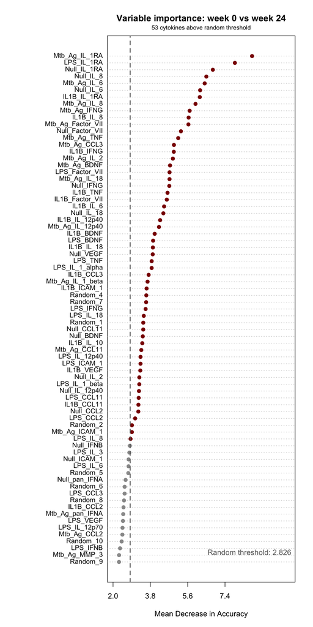

```
Saved: S4A_importance_W0_W24.png
```

```r
plot_importance_fig(
  importance_vals = avg_imp_24,
  rand_threshold  = threshold_24,
  title           = "Variable importance: week 0 vs week 24",
  save_path       = output_fig2a_s4a,
  filename        = "S4A_importance_W0_W24.png"
)
```

```r
set.seed(123)
roc_24 <- list()
for (cyt in top_cyts_24) {
  cat(sprintf("ROC: %s\n", cyt))
  roc_24[[cyt]] <- run_roc(
    data        = prep_24$data,
    cytokine    = cyt,
    n_bootstrap = rf_config$W0_W24$n_bootstrap_roc
  )
}
```

```
ROC: Mtb_Ag_IL_1RA
ROC: LPS_IL_1RA
ROC: Null_IL_1RA
ROC: Null_IL_8
```

```r
roc_24 <- Filter(Negate(is.null), roc_24)

for (cyt in names(roc_24)) {
  r <- roc_24[[cyt]]
  cat(sprintf("  %-20s AUC: %.3f (95%% CI: %.3f - %.3f) | Bootstrap n: %d\n",
              cyt, as.numeric(r$auc), r$ci_lower, r$ci_upper, r$n_valid_boot))
}
```

```
  Mtb_Ag_IL_1RA        AUC: 0.921 (95% CI: 0.858 - 0.976) | Bootstrap n: 2000
  LPS_IL_1RA           AUC: 0.903 (95% CI: 0.837 - 0.964) | Bootstrap n: 2000
  Null_IL_1RA          AUC: 0.861 (95% CI: 0.770 - 0.943) | Bootstrap n: 2000
  Null_IL_8            AUC: 0.830 (95% CI: 0.737 - 0.920) | Bootstrap n: 2000
```

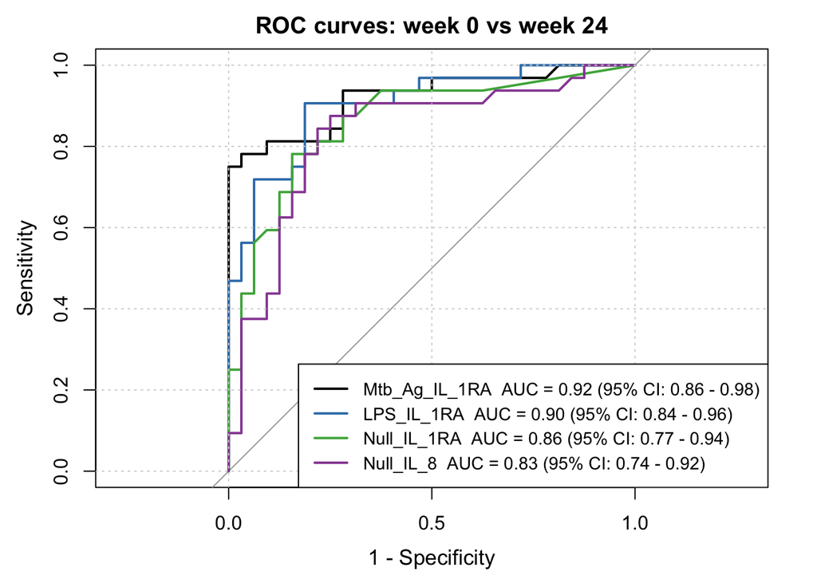

```
Saved: 2A_ROC_W0_W24.png
```

```r
plot_roc_curves(
  roc_results = roc_24,
  title       = "ROC curves: week 0 vs week 24",
  save_path   = output_fig2a_s4a,
  filename    = "2A_ROC_W0_W24.png"
)
```

```r
summary_24 <- build_summary(roc_24)
print(summary_24)
```

```
          Biomarker   AUC CI_Lower CI_Upper Optimal_Threshold Sensitivity_pct
2.5%  Mtb_Ag_IL_1RA 0.921    0.858    0.976            3.1564            78.1
2.5%1    LPS_IL_1RA 0.903    0.837    0.964            3.6758            90.6
2.5%2   Null_IL_1RA 0.861    0.770    0.943            2.3042            78.1
2.5%3     Null_IL_8 0.830    0.737    0.920            2.2460            87.5
      Specificity_pct PPV_pct NPV_pct Youden_J N_Bootstrap
2.5%             96.9    96.2    81.6    0.750        2000
2.5%1            81.2    82.9    89.7    0.719        2000
2.5%2            84.4    83.3    79.4    0.625        2000
2.5%3            75.0    77.8    85.7    0.625        2000
```

```r
write_xlsx(summary_24, file.path(output_fig2a_s4a, "ROC_summary_W0_W24.xlsx"))
```

# 12 week 0 vs week 72

```r
prep_72 <- prepare_rf_data(protein_log_wide, rf_config$W0_W72)
```

```
Visits: 0 vs 72 | Rows: 55 | Features retained: 86 | Random added: 10
```

```r
mtry_72 <- tune_rf(prep_72, rf_config$W0_W72)
```

```
Fold 1 leakage check - Train: 24 | Test: 8 | Overlap: 0
Best mtry: 7
Random Forest

55 samples
96 predictors
 2 classes: 'W0', 'W72'

No pre-processing
Resampling: Cross-Validated (10 fold)
Summary of sample sizes: 42, 45, 40, 47, 46
Resampling results across tuning parameters:

  mtry  ROC     Sens  Spec
  2     0.9075  0.91  0.9
  3     0.9175  0.91  0.9
  4     0.9175  0.91  0.9
  5     0.9175  0.91  0.9
  6     0.9175  0.91  0.9
  7     0.9300  0.91  0.9
  8     0.9300  0.91  0.9
  9     0.9175  0.91  0.9

ROC was used to select the optimal model using the largest value.
The final value used for the model was mtry = 7.
```

```r
bag_72  <- bag_rf(prep_72, mtry_72, rf_config$W0_W72)
```

```
Valid bags: 100 / 100
```

```r
avg_imp_72   <- bag_72$avg_importance
is_rand_72   <- grepl("^Random_", names(avg_imp_72))
threshold_72 <- mean(avg_imp_72[is_rand_72])
cyt_mda_72   <- avg_imp_72[!is_rand_72]
sig_72       <- sort(cyt_mda_72[cyt_mda_72 > threshold_72], decreasing = TRUE)
top_cyts_72  <- names(head(sig_72, rf_config$W0_W72$top_n_cytokines))

cat(sprintf(
  "Threshold: %.3f | Cytokines above threshold: %d | Top %d: %s\n",
  threshold_72, length(sig_72), length(top_cyts_72),
  paste(top_cyts_72, collapse = ", ")
))
```

```
Threshold: 1.920 | Cytokines above threshold: 59 | Top 4: LPS_IL_1RA, Mtb_Ag_IL_1RA, Mtb_Ag_IL_8, IL1B_IL_1RA
```

```r
print(sig_72)
```

```
       LPS_IL_1RA     Mtb_Ag_IL_1RA       Mtb_Ag_IL_8       IL1B_IL_1RA
         8.518849          8.198784          7.175557          6.670202
        Null_IFNG       Mtb_Ag_IL_6       Mtb_Ag_IFNG       Null_IL_1RA
         6.562601          6.293056          6.147905          5.658169
       Mtb_Ag_TNF         Null_IL_8         IL1B_IL_8       Mtb_Ag_CCL3
         5.417285          5.144485          5.083231          5.058657
       Null_IL_18         IL1B_IFNG         IL1B_IL_6          LPS_BDNF
         5.003900          4.849863          4.656478          4.592180
     Mtb_Ag_IL_18       Mtb_Ag_IL_2         Null_IL_6        IL1B_IL_10
         4.483958          4.345028          4.080483          4.048582
    IL1B_IL_12p40       IL1B_ICAM_1        IL1B_IL_18       Mtb_Ag_BDNF
         3.812053          3.668738          3.598503          3.535274
         IL1B_TNF   Mtb_Ag_IL_12p40         LPS_IL_18          LPS_CCL2
         3.514936          3.467067          3.466500          3.345237
 Mtb_Ag_IL_1_beta         Null_BDNF         IL1B_BDNF         Null_VEGF
         3.316744          3.268985          3.248774          3.078779
   LPS_IL_1_alpha         IL1B_CCL3      LPS_IL_12p70     LPS_IL_1_beta
         3.031534          2.958823          2.886356          2.872429
       LPS_ICAM_1      LPS_IL_12p40         LPS_IL_10          LPS_IFNG
         2.851183          2.622024          2.622016          2.621355
    Mtb_Ag_ICAM_1          LPS_VEGF         IL1B_VEGF           LPS_TNF
         2.602090          2.533229          2.409826          2.370237
         LPS_IL_3       Null_ICAM_1     Null_IL_12p40      Mtb_Ag_CCL11
         2.352929          2.341140          2.283338          2.281639
    Null_pan_IFNA Mtb_Ag_Factor_VII        Null_CCL11   IL1B_Factor_VII
         2.155110          2.104518          2.075340          2.070158
   LPS_Factor_VII       Mtb_Ag_CCL2        IL1B_CCL11         LPS_CCL11
         2.065384          2.058169          2.052267          2.025935
        IL1B_CCL2      LPS_pan_IFNA          LPS_CCL3
         2.008171          1.995452          1.940684
```

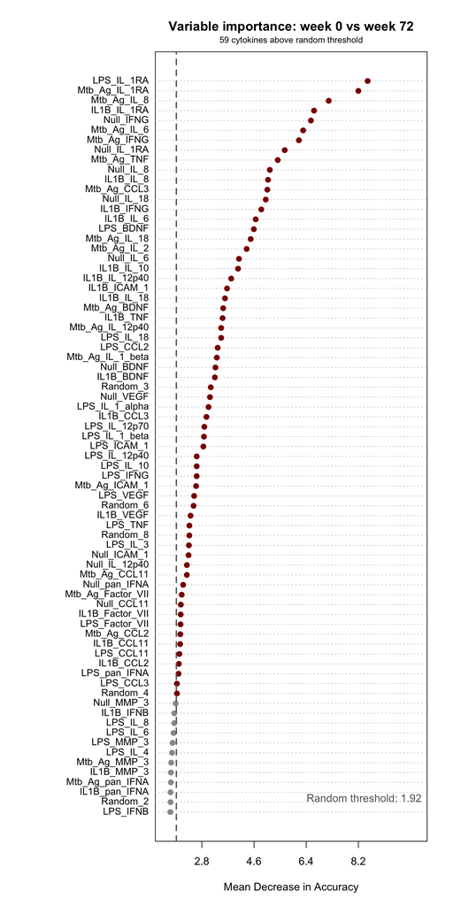

```
Saved: S4A_importance_W0_W72.png
```

```r
plot_importance_fig(
  importance_vals = avg_imp_72,
  rand_threshold  = threshold_72,
  title           = "Variable importance: week 0 vs week 72",
  save_path       = output_fig2a_s4a,
  filename        = "S4A_importance_W0_W72.png"
)
```

```r
set.seed(123)
roc_72 <- list()
for (cyt in top_cyts_72) {
  cat(sprintf("ROC: %s\n", cyt))
  roc_72[[cyt]] <- run_roc(
    data        = prep_72$data,
    cytokine    = cyt,
    n_bootstrap = rf_config$W0_W72$n_bootstrap_roc
  )
}
```

```
ROC: LPS_IL_1RA
ROC: Mtb_Ag_IL_1RA
ROC: Mtb_Ag_IL_8
ROC: IL1B_IL_1RA
```

```r
roc_72 <- Filter(Negate(is.null), roc_72)

for (cyt in names(roc_72)) {
  r <- roc_72[[cyt]]
  cat(sprintf("  %-20s AUC: %.3f (95%% CI: %.3f - %.3f) | Bootstrap n: %d\n",
              cyt, as.numeric(r$auc), r$ci_lower, r$ci_upper, r$n_valid_boot))
}
```

```
  LPS_IL_1RA           AUC: 0.924 (95% CI: 0.832 - 0.991) | Bootstrap n: 2000
  Mtb_Ag_IL_1RA        AUC: 0.954 (95% CI: 0.903 - 0.999) | Bootstrap n: 2000
  Mtb_Ag_IL_8          AUC: 0.908 (95% CI: 0.820 - 0.983) | Bootstrap n: 2000
  IL1B_IL_1RA          AUC: 0.905 (95% CI: 0.824 - 0.973) | Bootstrap n: 2000
```

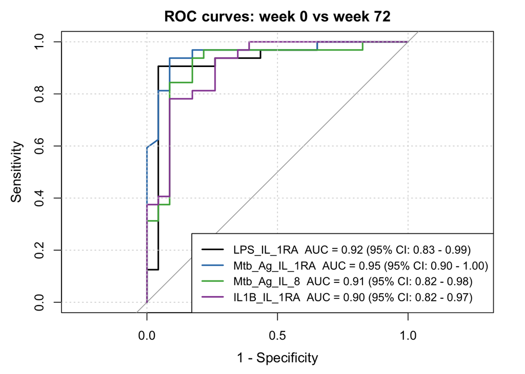

```
Saved: 2A_ROC_W0_W72.png
```

```r
plot_roc_curves(
  roc_results = roc_72,
  title       = "ROC curves: week 0 vs week 72",
  save_path   = output_fig2a_s4a,
  filename    = "2A_ROC_W0_W72.png"
)
```

```r
summary_72 <- build_summary(roc_72)
print(summary_72)
```

```
          Biomarker   AUC CI_Lower CI_Upper Optimal_Threshold Sensitivity_pct
2.5%     LPS_IL_1RA 0.924    0.832    0.991            3.6767            90.6
2.5%1 Mtb_Ag_IL_1RA 0.954    0.903    0.999            2.6203            93.8
2.5%2   Mtb_Ag_IL_8 0.908    0.820    0.983            3.0549            93.8
2.5%3   IL1B_IL_1RA 0.905    0.824    0.973            2.5820            78.1
      Specificity_pct PPV_pct NPV_pct Youden_J N_Bootstrap
2.5%             95.7    96.7    88.0    0.863        2000
2.5%1            91.3    93.8    91.3    0.851        2000
2.5%2            82.6    88.2    90.5    0.764        2000
2.5%3            91.3    92.6    75.0    0.694        2000
```

```r
write_xlsx(summary_72, file.path(output_fig2a_s4a, "ROC_summary_W0_W72.xlsx"))
```